# Course project Practical Machine Learning

Ramya Rao

Thursday, September 24, 2015

### Problem context

The goal of the project is to predict the manner in which users did the exercise. This is the “classe” variable in the training set. Check the course website for the complete problem context.

### Load data

Download the training and evaluation data from the below location.

```r
download.file("http://d396qusza40orc.cloudfront.net/predmachlearn/pml-training.csv", destfile = "./pml-training.csv")
download.file("http://d396qusza40orc.cloudfront.net/predmachlearn/pml-testing.csv", destfile = "./pml-testing.csv")

trainData = read.csv("pml-training.csv", na.strings=c("", "NA", "NULL"))
evalData = read.csv("pml-testing.csv", na.strings=c("", "NA", "NULL"))
```

### Prepare data for consumption

We will consider only the trainData for predicting.

We can see that this dataset has the following number of rows and columns.

```r
dim(trainData)
```

```
## [1] 19622   160
```

Not all of the columns or predictors truly influence the prediction model, hence we reduce the number of columns/predictors. Remove columns with empty values

```r
trainNonEmpty <- trainData[ , colSums(is.na(trainData)) == 0]
```

Remove columns with near zero variance

```r
library(caret)
zv <- nearZeroVar(trainNonEmpty[sapply(trainNonEmpty, is.numeric)], saveMetrics=TRUE)
trainNonZV<-trainNonEmpty[,zv[, 'nzv']==0]
```

Remove columns that do not have any impact on the prediction model

```r
nonPredictCols = c( "X","user_name","raw_timestamp_part_1","raw_timestamp_part_2","cvtd_timestamp","new_window","num_window")
trainNonPred = trainNonZV[,-which(names(trainNonZV)%in%nonPredictCols)]
```

Remove columns with high correlation

```r
correlations <- cor(na.omit(trainNonPred[sapply(trainNonPred, is.numeric)]))
corrCols = findCorrelation(correlations, cutoff = .90, verbose = TRUE)
```

```
## Compare row 10  and column  1 with corr  0.992
##   Means:  0.27 vs 0.168 so flagging column 10
## Compare row 1  and column  9 with corr  0.925
##   Means:  0.25 vs 0.164 so flagging column 1
## Compare row 9  and column  4 with corr  0.928
##   Means:  0.233 vs 0.161 so flagging column 9
## Compare row 8  and column  2 with corr  0.966
##   Means:  0.245 vs 0.157 so flagging column 8
## Compare row 19  and column  18 with corr  0.918
##   Means:  0.091 vs 0.158 so flagging column 18
## Compare row 46  and column  31 with corr  0.914
##   Means:  0.101 vs 0.161 so flagging column 31
## Compare row 46  and column  33 with corr  0.933
##   Means:  0.083 vs 0.164 so flagging column 33
## All correlations <= 0.9
```

```r
trainNoCor = trainNonPred[,-corrCols]
```

From the above we see that our training data has been trimmed to te following number of rows and columns.

```r
dim(trainNoCor)
```

```
## [1] 19622    46
```

### Sampling data

Split the training data into training and testing subsets, the training subset will be used to train models, while the testing subset will be used to validate the model and compare to other methods.

```r
tempTrain <- createDataPartition(y=trainNoCor$classe, p=0.7, list=FALSE)

forTraining <- trainNoCor[tempTrain,];
forTesting <- trainNoCor[-tempTrain,]
dim(forTraining);dim(forTesting)
```

```
## [1] 13737    46
```

```
## [1] 5885   46
```

### Prediction and cross validation.

We will consider three learning methods for analysis - Tree, Recursive partioning and Random forests.

#### Tree

```r
library(tree)
set.seed(12345)
treetraining=tree(classe~.,data=forTraining)
summary(treetraining)
```

```
##
## Classification tree:
## tree(formula = classe ~ ., data = forTraining)
## Variables actually used in tree construction:
##  [1] "pitch_forearm"     "magnet_belt_y"     "accel_forearm_z"
##  [4] "magnet_dumbbell_y" "roll_forearm"      "magnet_dumbbell_z"
##  [7] "pitch_belt"        "yaw_belt"          "accel_forearm_x"
## [10] "magnet_arm_x"      "accel_dumbbell_z"
## Number of terminal nodes:  18
## Residual mean deviance:  1.755 = 24080 / 13720
## Misclassification error rate: 0.3513 = 4826 / 13737
```

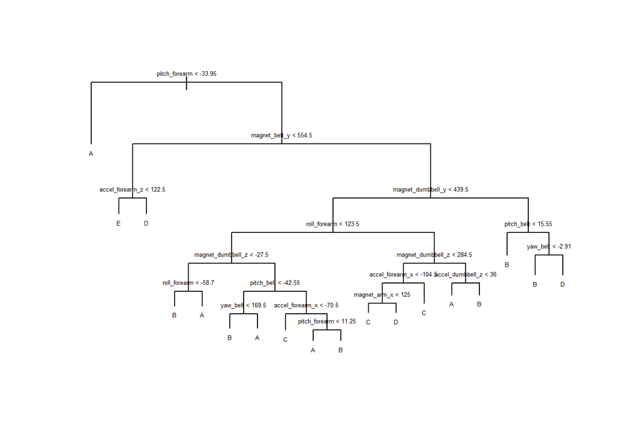

```r
plot(treetraining)
text(treetraining,pretty=0, cex =.4)
```

```r
treepred=predict(treetraining,forTesting,type="class")
confusionMatrix(treepred, forTesting$classe)
```

```
## Confusion Matrix and Statistics
##
##           Reference
## Prediction    A    B    C    D    E
##          A 1462  197  120   76   20
##          B  129  712  121  119  407
##          C   46  218  760  305  293
##          D   37   12   25  464   43
##          E    0    0    0    0  319
##
## Overall Statistics
##
##                Accuracy : 0.6316
##                  95% CI : (0.6191, 0.6439)
##     No Information Rate : 0.2845
##     P-Value [Acc > NIR] : < 2.2e-16
##
##                   Kappa : 0.5315
##  Mcnemar's Test P-Value : < 2.2e-16
##
## Statistics by Class:
##
##                      Class: A Class: B Class: C Class: D Class: E
## Sensitivity            0.8734   0.6251   0.7407  0.48133  0.29482
## Specificity            0.9019   0.8365   0.8226  0.97622  1.00000
## Pos Pred Value         0.7797   0.4785   0.4686  0.79862  1.00000
## Neg Pred Value         0.9471   0.9029   0.9376  0.90573  0.86292
## Prevalence             0.2845   0.1935   0.1743  0.16381  0.18386
## Detection Rate         0.2484   0.1210   0.1291  0.07884  0.05421
## Detection Prevalence   0.3186   0.2528   0.2756  0.09873  0.05421
## Balanced Accuracy      0.8876   0.7308   0.7817  0.72878  0.64741
```

#### Recursive partitioning

```r
rpartModel <- train(classe ~ .,method="rpart",data=forTraining)
```

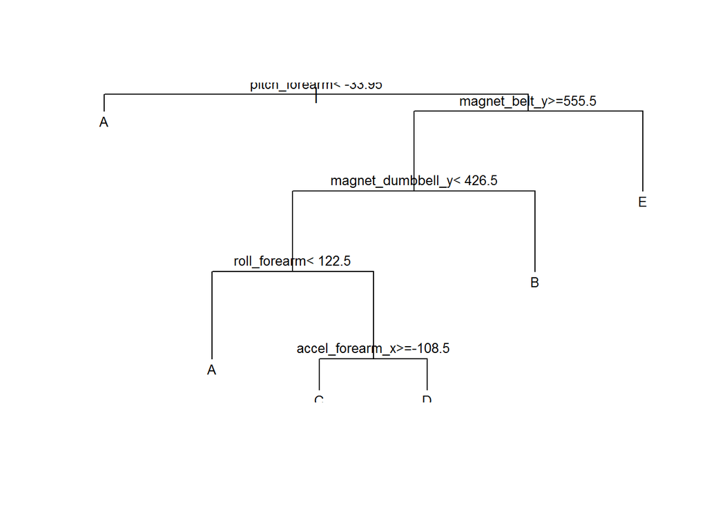

```r
plot(rpartModel$finalModel)
text(rpartModel$finalModel,pretty=0, cex =.8)
```

```r
rpartpred=predict(rpartModel$finalModel, forTesting, type="class")
confusionMatrix(rpartpred, forTesting$classe)
```

```
## Confusion Matrix and Statistics
##
##           Reference
## Prediction    A    B    C    D    E
##          A 1512  463  471  361  218
##          B   36  403   39  205  245
##          C   87  229  408   97  254
##          D   38   42  108  207   30
##          E    1    2    0   94  335
##
## Overall Statistics
##
##                Accuracy : 0.4868
##                  95% CI : (0.474, 0.4997)
##     No Information Rate : 0.2845
##     P-Value [Acc > NIR] : < 2.2e-16
##
##                   Kappa : 0.3301
##  Mcnemar's Test P-Value : < 2.2e-16
##
## Statistics by Class:
##
##                      Class: A Class: B Class: C Class: D Class: E
## Sensitivity            0.9032  0.35382  0.39766  0.21473  0.30961
## Specificity            0.6407  0.88938  0.86273  0.95570  0.97980
## Pos Pred Value         0.4998  0.43427  0.37953  0.48706  0.77546
## Neg Pred Value         0.9434  0.85152  0.87152  0.86136  0.86301
## Prevalence             0.2845  0.19354  0.17434  0.16381  0.18386
## Detection Rate         0.2569  0.06848  0.06933  0.03517  0.05692
## Detection Prevalence   0.5140  0.15769  0.18267  0.07222  0.07341
## Balanced Accuracy      0.7720  0.62160  0.63019  0.58522  0.64471
```

#### Random forest

```r
require(randomForest)
set.seed(12345)

rfTraining=randomForest(classe~.,data=forTraining,ntree=100, importance=TRUE)
summary(rfTraining)
```

```
##                 Length Class  Mode
## call                5  -none- call
## type                1  -none- character
## predicted       13737  factor numeric
## err.rate          600  -none- numeric
## confusion          30  -none- numeric
## votes           68685  matrix numeric
## oob.times       13737  -none- numeric
## classes             5  -none- character
## importance        315  -none- numeric
## importanceSD      270  -none- numeric
## localImportance     0  -none- NULL
## proximity           0  -none- NULL
## ntree               1  -none- numeric
## mtry                1  -none- numeric
## forest             14  -none- list
## y               13737  factor numeric
## test                0  -none- NULL
## inbag               0  -none- NULL
## terms               3  terms  call
```

```r
rfpred <- predict(rfTraining, forTesting,type="class")
confusionMatrix(rfpred, forTesting$classe)
```

```
## Confusion Matrix and Statistics
##
##           Reference
## Prediction    A    B    C    D    E
##          A 1674    6    0    0    0
##          B    0 1128    4    0    0
##          C    0    5 1022    8    0
##          D    0    0    0  954    1
##          E    0    0    0    2 1081
##
## Overall Statistics
##
##                Accuracy : 0.9956
##                  95% CI : (0.9935, 0.9971)
##     No Information Rate : 0.2845
##     P-Value [Acc > NIR] : < 2.2e-16
##
##                   Kappa : 0.9944
##  Mcnemar's Test P-Value : NA
##
## Statistics by Class:
##
##                      Class: A Class: B Class: C Class: D Class: E
## Sensitivity            1.0000   0.9903   0.9961   0.9896   0.9991
## Specificity            0.9986   0.9992   0.9973   0.9998   0.9996
## Pos Pred Value         0.9964   0.9965   0.9874   0.9990   0.9982
## Neg Pred Value         1.0000   0.9977   0.9992   0.9980   0.9998
## Prevalence             0.2845   0.1935   0.1743   0.1638   0.1839
## Detection Rate         0.2845   0.1917   0.1737   0.1621   0.1837
## Detection Prevalence   0.2855   0.1924   0.1759   0.1623   0.1840
## Balanced Accuracy      0.9993   0.9947   0.9967   0.9947   0.9993
```

### Conclusion

Below is the prediction applied to the testset.

```r
finalAnswers <- predict(rfTraining, evalData)
finalAnswers
```

```
##  1  2  3  4  5  6  7  8  9 10 11 12 13 14 15 16 17 18 19 20
##  B  A  B  A  A  E  D  B  A  A  B  C  B  A  E  E  A  B  B  B
## Levels: A B C D E
```